# Social Network Analysis

Analysis

Federico Bianchi

# 1 Introduction

- This is a notebook for hands-on sessions of the Social Network Analysis course for Ph.D. students of the NASP doctoral school, University of Milan (Italy).
- Analysed data are taken from

Bianchi, F., Casnici, N., & Squazzoni, F. (2018). Solidarity as a byproduct of professional collaboration. Social support and trust in a coworking space. *Social Networks*, 54: 61-72. doi: https://doi.org/10.1016/j.socnet.2017.12.002.

# 2 Packages

It is good practice to upload the needed packages at the beginning of your notebook.

```r
library(tidyverse)
library(here)
```

```r
library(igraph)
library(ggraph)
library(tidygraph)
library(purrr)
```

# 3 Collaboration

## 3.1 Loading data

- Now, we need to import data on *collaboration* relationships.
- In order to let `R` find the data, we need to move the data file to the same directory where our Rstudio project is located (i.e., the *working directory*)

If you don’t remember what working directory you’re in:

```r
getwd()
```

```
## [1] "/Users/federico/Desktop/sna"
```

- Let’s inspect the data structure: we could either open the file outside Rstudio or even from within
- It’s a .txt file.
- It’s an **adjacency matrix** (see [slides](https://federico-bianchi.github.io/teaching/))
- Values are 0 and 1 and are separated by a tab (`\t`)
- In order to load it, we need a function to read a table data structure.
- `read.table` is classic R, while `readr::read_delim` is faster. It’s included in the `tidyverse`, which we have already uploaded.

Now we can inspect the `read_delim` function in the console, by hitting

```r
?read_delim
```

What information do we need? * the file name: `collaboration.txt` * the column separator: `"\t"` * whether we have column names: no

Where is my data file?

```r
dir()
```

```
## [1] "data"                     "sna-notebook_teacher.Rmd"
## [3] "sna-notebook.html"        "sna-notebook.nb.html"
## [5] "sna-notebook.Rmd"         "sna.Rproj"
```

In order to maximise reproducibility, we need the path to be available to all possible colleagues. We can use the `here::here` function, which builds a new path regardless of the original path.

The function `here()` finds my working directory and builds a plausible path towards the specified arguments.

```r
here("data", "collaboration.txt")
```

```
## [1] "/Users/federico/Desktop/sna/data/collaboration.txt"
```

Now we’re ready to load collaboration data as a new object. We can use `read_tsv`, which takes `"\t"` as a default value of the `delim` parameter

```r
here("data", "collaboration.txt") %>%
  read_tsv(col_names = FALSE)
```

| X1 | X2 | X3 | X4 | X5 | X6 | X7 | X8 | X9 | X10 | X11 | X12 | X13 | X14 | X15 | X16 | X17 | X18 | X19 | X20 | X21 | X22 | X23 | X24 | X25 | X26 | X27 | X28 | X29 |
| --- | --- | --- | --- | --- | --- | --- | --- | --- | --- | --- | --- | --- | --- | --- | --- | --- | --- | --- | --- | --- | --- | --- | --- | --- | --- | --- | --- | --- |
| 0 | 0 | 0 | 0 | 0 | 0 | 0 | 0 | 0 | 0 | 0 | 1 | 0 | 0 | 0 | 0 | 0 | 0 | 0 | 0 | 0 | 0 | 0 | 0 | 0 | 0 | 0 | 0 | 0 |
| 0 | 0 | 0 | 1 | 0 | 0 | 1 | 1 | 1 | 1 | 0 | 0 | 1 | 1 | 1 | 1 | 0 | 0 | 0 | 0 | 0 | 0 | 0 | 0 | 0 | 0 | 0 | 0 | 0 |
| 0 | 0 | 0 | 0 | 0 | 1 | 0 | 1 | 1 | 1 | 0 | 0 | 0 | 1 | 0 | 0 | 0 | 0 | 1 | 1 | 0 | 0 | 1 | 0 | 1 | 1 | 1 | 1 | 0 |
| 0 | 1 | 0 | 0 | 0 | 0 | 0 | 0 | 1 | 1 | 0 | 0 | 0 | 1 | 0 | 0 | 0 | 0 | 0 | 0 | 0 | 0 | 0 | 0 | 0 | 0 | 0 | 0 | 0 |
| 0 | 0 | 0 | 0 | 0 | 0 | 0 | 0 | 0 | 0 | 0 | 0 | 0 | 0 | 0 | 0 | 0 | 0 | 0 | 0 | 0 | 0 | 0 | 0 | 0 | 0 | 0 | 0 | 0 |
| 0 | 0 | 1 | 0 | 0 | 0 | 0 | 0 | 1 | 1 | 0 | 0 | 1 | 0 | 1 | 1 | 1 | 0 | 1 | 1 | 0 | 0 | 1 | 0 | 0 | 0 | 0 | 0 | 0 |
| 0 | 1 | 0 | 0 | 0 | 0 | 0 | 0 | 0 | 0 | 0 | 0 | 0 | 0 | 0 | 0 | 0 | 0 | 0 | 0 | 1 | 0 | 0 | 0 | 0 | 0 | 0 | 0 | 0 |
| 0 | 1 | 1 | 0 | 0 | 0 | 0 | 0 | 0 | 1 | 0 | 0 | 0 | 0 | 0 | 0 | 0 | 0 | 1 | 0 | 1 | 0 | 0 | 0 | 0 | 0 | 1 | 1 | 0 |
| 0 | 1 | 1 | 1 | 0 | 1 | 0 | 0 | 0 | 0 | 0 | 0 | 0 | 1 | 0 | 0 | 0 | 0 | 1 | 1 | 0 | 0 | 1 | 0 | 0 | 0 | 0 | 0 | 0 |
| 0 | 1 | 1 | 1 | 0 | 1 | 0 | 1 | 0 | 0 | 0 | 0 | 1 | 0 | 1 | 1 | 0 | 0 | 1 | 1 | 1 | 0 | 1 | 0 | 0 | 1 | 1 | 1 | 0 |

[output cut: 19 more lines]

What kind of object have we stored our data in?

```r
here("data", "collaboration.txt") %>%
  read_tsv(col_names = FALSE) %>%
  class()
```

```
## [1] "spec_tbl_df" "tbl_df"      "tbl"         "data.frame"
```

It’s a `tibble`, the `tidyverse` version of a `data.frame`.

Let’s inspect our data

```r
here("data", "collaboration.txt") %>%
  read_tsv(col_names = FALSE) %>%
  str()
```

```
## spc_tbl_ [29 × 29] (S3: spec_tbl_df/tbl_df/tbl/data.frame)
##  $ X1 : num [1:29] 0 0 0 0 0 0 0 0 0 0 ...
##  $ X2 : num [1:29] 0 0 0 1 0 0 1 1 1 1 ...
##  $ X3 : num [1:29] 0 0 0 0 0 1 0 1 1 1 ...
##  $ X4 : num [1:29] 0 1 0 0 0 0 0 0 1 1 ...
##  $ X5 : num [1:29] 0 0 0 0 0 0 0 0 0 0 ...
##  $ X6 : num [1:29] 0 0 1 0 0 0 0 0 1 1 ...
##  $ X7 : num [1:29] 0 1 0 0 0 0 0 0 0 0 ...
##  $ X8 : num [1:29] 0 1 1 0 0 0 0 0 0 1 ...
##  $ X9 : num [1:29] 0 1 1 1 0 1 0 0 0 0 ...
##  $ X10: num [1:29] 0 1 1 1 0 1 0 1 0 0 ...
##  $ X11: num [1:29] 0 0 0 0 0 0 0 0 0 0 ...
##  $ X12: num [1:29] 1 0 0 0 0 0 0 0 0 0 ...
##  $ X13: num [1:29] 0 1 0 0 0 1 0 0 0 1 ...
##  $ X14: num [1:29] 0 1 1 1 0 0 0 0 1 0 ...
##  $ X15: num [1:29] 0 1 0 0 0 1 0 0 0 1 ...
##  $ X16: num [1:29] 0 1 0 0 0 1 0 0 0 1 ...
##  $ X17: num [1:29] 0 0 0 0 0 1 0 0 0 0 ...
##  $ X18: num [1:29] 0 0 0 0 0 0 0 0 0 0 ...
##  $ X19: num [1:29] 0 0 1 0 0 1 0 1 1 1 ...
##  $ X20: num [1:29] 0 0 1 0 0 1 0 0 1 1 ...
##  $ X21: num [1:29] 0 0 0 0 0 0 1 1 0 1 ...
##  $ X22: num [1:29] 0 0 0 0 0 0 0 0 0 0 ...
##  $ X23: num [1:29] 0 0 1 0 0 1 0 0 1 1 ...
##  $ X24: num [1:29] 0 0 0 0 0 0 0 0 0 0 ...
##  $ X25: num [1:29] 0 0 1 0 0 0 0 0 0 0 ...
##  $ X26: num [1:29] 0 0 1 0 0 0 0 0 0 1 ...
##  $ X27: num [1:29] 0 0 1 0 0 0 0 1 0 1 ...
##  $ X28: num [1:29] 0 0 1 0 0 0 0 1 0 1 ...
##  $ X29: num [1:29] 0 0 0 0 0 0 0 0 0 0 ...
##  - attr(*, "spec")=
##   .. cols(
##   ..   X1 = col_double(),
##   ..   X2 = col_double(),
##   ..   X3 = col_double(),
##   ..   X4 = col_double(),
##   ..   X5 = col_double(),
##   ..   X6 = col_double(),
##   ..   X7 = col_double(),
##   ..   X8 = col_double(),
```

[output cut: 8 more lines]

```
##   ..   X17 = col_double(),
##   ..   X18 = col_double(),
##   ..   X19 = col_double(),
##   ..   X20 = col_double(),
##   ..   X21 = col_double(),
##   ..   X22 = col_double(),
##   ..   X23 = col_double(),
##   ..   X24 = col_double(),
##   ..   X25 = col_double(),
##   ..   X26 = col_double(),
##   ..   X27 = col_double(),
##   ..   X28 = col_double(),
##   ..   X29 = col_double()
##   .. )
##  - attr(*, "problems")=<externalptr>
```

- It’s interpreted as a case-by-variable matrix, with 29 variables.
- Instead, what we need is an adjacency matrix.

```r
here("data", "collaboration.txt") %>%
  read_tsv(col_names = FALSE) %>%
  as.matrix()
```

```
##       X1 X2 X3 X4 X5 X6 X7 X8 X9 X10 X11 X12 X13 X14 X15 X16 X17 X18 X19 X20
##  [1,]  0  0  0  0  0  0  0  0  0   0   0   1   0   0   0   0   0   0   0   0
##  [2,]  0  0  0  1  0  0  1  1  1   1   0   0   1   1   1   1   0   0   0   0
##  [3,]  0  0  0  0  0  1  0  1  1   1   0   0   0   1   0   0   0   0   1   1
##  [4,]  0  1  0  0  0  0  0  0  1   1   0   0   0   1   0   0   0   0   0   0
##  [5,]  0  0  0  0  0  0  0  0  0   0   0   0   0   0   0   0   0   0   0   0
##  [6,]  0  0  1  0  0  0  0  0  1   1   0   0   1   0   1   1   1   0   1   1
##  [7,]  0  1  0  0  0  0  0  0  0   0   0   0   0   0   0   0   0   0   0   0
##  [8,]  0  1  1  0  0  0  0  0  0   1   0   0   0   0   0   0   0   0   1   0
##  [9,]  0  1  1  1  0  1  0  0  0   0   0   0   0   1   0   0   0   0   1   1
## [10,]  0  1  1  1  0  1  0  1  0   0   0   0   1   0   1   1   0   0   1   1
## [11,]  0  0  0  0  0  0  0  0  0   0   0   0   0   0   0   0   0   0   0   0
## [12,]  1  0  0  0  0  0  0  0  0   0   0   0   0   0   0   0   0   0   0   0
## [13,]  0  1  0  0  0  1  0  0  0   1   0   0   0   0   1   1   0   0   0   1
## [14,]  0  1  1  1  0  0  0  0  1   0   0   0   0   0   0   0   0   0   0   0
```

[output cut: 45 more lines]

Now our data are interpreted by `R` as a matrix.

```r
here("data", "collaboration.txt") %>%
  read_tsv(col_names = FALSE) %>%
  as.matrix() %>%
  class()
```

```
## [1] "matrix" "array"
```

## 3.2 From data to graphs

- In order to apply some SNA functions, we need to use the `igraph` package, which handles our data as `igraph` objects, to which its functions can be applied
- We have to turn our data into an `igraph` object.
- There’s a series of primitives starting with `graph_from` that can be useful for us
- We need to specify that the matrix should be interpreted as undirected graph

```r
here("data", "collaboration.txt") %>%
  read_tsv(col_names = FALSE) %>%
  as.matrix() %>%
  graph_from_adjacency_matrix(mode = "undirected")
```

```
## IGRAPH 974219b UN-- 29 82 --
## + attr: name (v/c)
## + edges from 974219b (vertex names):
##  [1] X1 --X12 X2 --X4  X2 --X7  X2 --X8  X2 --X9  X2 --X10 X2 --X13 X2 --X14
##  [9] X2 --X15 X2 --X16 X3 --X6  X3 --X8  X3 --X9  X3 --X10 X3 --X14 X3 --X19
## [17] X3 --X20 X3 --X23 X3 --X25 X3 --X26 X3 --X27 X3 --X28 X4 --X9  X4 --X10
## [25] X4 --X14 X6 --X9  X6 --X10 X6 --X13 X6 --X15 X6 --X16 X6 --X17 X6 --X19
## [33] X6 --X20 X6 --X23 X7 --X21 X8 --X10 X8 --X19 X8 --X21 X8 --X27 X8 --X28
## [41] X9 --X14 X9 --X19 X9 --X20 X9 --X23 X10--X13 X10--X15 X10--X16 X10--X19
## [49] X10--X20 X10--X21 X10--X23 X10--X26 X10--X27 X10--X28 X13--X15 X13--X16
## [57] X13--X20 X13--X22 X13--X23 X15--X16 X15--X20 X15--X22 X15--X23 X16--X20
## + ... omitted several edges
```

The summary shows us: * that the network is undirected (UN) * 29 nodes * 82 links * the list of the edges

An `igraph` object is a complex R object made of lists

```r
here("data", "collaboration.txt") %>%
  read_tsv(col_names = FALSE) %>%
  as.matrix() %>%
  graph_from_adjacency_matrix(mode = "undirected")
```

```
## IGRAPH 81b9fe0 UN-- 29 82 --
## + attr: name (v/c)
## + edges from 81b9fe0 (vertex names):
##  [1] X1 --X12 X2 --X4  X2 --X7  X2 --X8  X2 --X9  X2 --X10 X2 --X13 X2 --X14
##  [9] X2 --X15 X2 --X16 X3 --X6  X3 --X8  X3 --X9  X3 --X10 X3 --X14 X3 --X19
## [17] X3 --X20 X3 --X23 X3 --X25 X3 --X26 X3 --X27 X3 --X28 X4 --X9  X4 --X10
## [25] X4 --X14 X6 --X9  X6 --X10 X6 --X13 X6 --X15 X6 --X16 X6 --X17 X6 --X19
## [33] X6 --X20 X6 --X23 X7 --X21 X8 --X10 X8 --X19 X8 --X21 X8 --X27 X8 --X28
## [41] X9 --X14 X9 --X19 X9 --X20 X9 --X23 X10--X13 X10--X15 X10--X16 X10--X19
## [49] X10--X20 X10--X21 X10--X23 X10--X26 X10--X27 X10--X28 X13--X15 X13--X16
## [57] X13--X20 X13--X22 X13--X23 X15--X16 X15--X20 X15--X22 X15--X23 X16--X20
## + ... omitted several edges
```

Because we will then use the graph to perform analyses, we need it to be stored in an object.

```r
(collaboration <-
  here("data", "collaboration.txt") %>%
  read_delim(col_names = FALSE) %>%
  as.matrix() %>%
  graph_from_adjacency_matrix(mode = "undirected"))
```

```
## IGRAPH 2fe0827 UN-- 29 82 --
## + attr: name (v/c)
## + edges from 2fe0827 (vertex names):
##  [1] X1 --X12 X2 --X4  X2 --X7  X2 --X8  X2 --X9  X2 --X10 X2 --X13 X2 --X14
##  [9] X2 --X15 X2 --X16 X3 --X6  X3 --X8  X3 --X9  X3 --X10 X3 --X14 X3 --X19
## [17] X3 --X20 X3 --X23 X3 --X25 X3 --X26 X3 --X27 X3 --X28 X4 --X9  X4 --X10
## [25] X4 --X14 X6 --X9  X6 --X10 X6 --X13 X6 --X15 X6 --X16 X6 --X17 X6 --X19
## [33] X6 --X20 X6 --X23 X7 --X21 X8 --X10 X8 --X19 X8 --X21 X8 --X27 X8 --X28
## [41] X9 --X14 X9 --X19 X9 --X20 X9 --X23 X10--X13 X10--X15 X10--X16 X10--X19
## [49] X10--X20 X10--X21 X10--X23 X10--X26 X10--X27 X10--X28 X13--X15 X13--X16
## [57] X13--X20 X13--X22 X13--X23 X15--X16 X15--X20 X15--X22 X15--X23 X16--X20
## + ... omitted several edges
```

## 3.3 Visualization

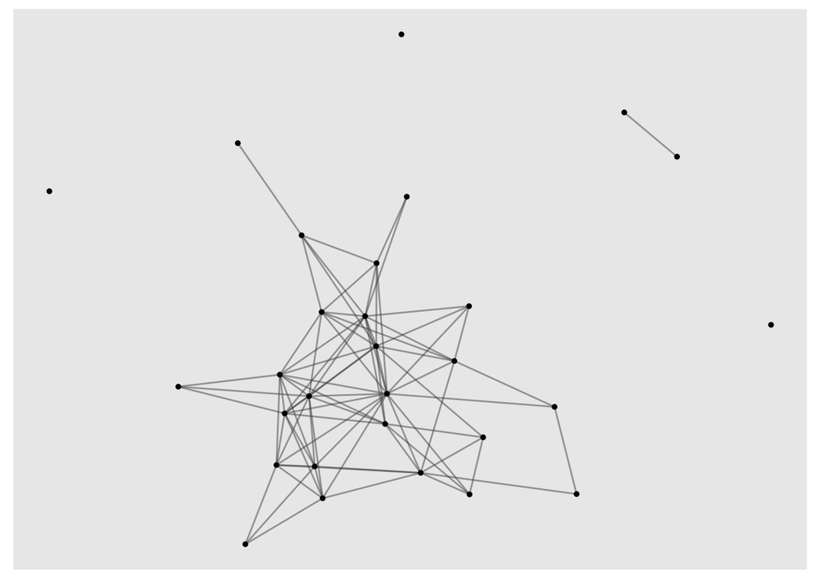

```r
collaboration %>%
  ggraph(layout = "fr") +
  geom_edge_link(
    colour = "grey30",
    width = .5,
    alpha = .5
  ) +
  geom_node_point(
    size = 1
  )
```

## 3.4 Connectivity

A basic *graph-level* network property we could be interested in is how *connected* a network is

Let’s start from the number of edges

```r
ecount(collaboration)
```

```
## [1] 82
```

We can also retrieve the whole list of edges

```r
E(collaboration)
```

```
## + 82/82 edges from 2fe0827 (vertex names):
##  [1] X1 --X12 X2 --X4  X2 --X7  X2 --X8  X2 --X9  X2 --X10 X2 --X13 X2 --X14
##  [9] X2 --X15 X2 --X16 X3 --X6  X3 --X8  X3 --X9  X3 --X10 X3 --X14 X3 --X19
## [17] X3 --X20 X3 --X23 X3 --X25 X3 --X26 X3 --X27 X3 --X28 X4 --X9  X4 --X10
## [25] X4 --X14 X6 --X9  X6 --X10 X6 --X13 X6 --X15 X6 --X16 X6 --X17 X6 --X19
## [33] X6 --X20 X6 --X23 X7 --X21 X8 --X10 X8 --X19 X8 --X21 X8 --X27 X8 --X28
## [41] X9 --X14 X9 --X19 X9 --X20 X9 --X23 X10--X13 X10--X15 X10--X16 X10--X19
## [49] X10--X20 X10--X21 X10--X23 X10--X26 X10--X27 X10--X28 X13--X15 X13--X16
## [57] X13--X20 X13--X22 X13--X23 X15--X16 X15--X20 X15--X22 X15--X23 X16--X20
## [65] X16--X22 X17--X20 X17--X23 X18--X25 X19--X20 X19--X23 X19--X24 X19--X25
## [73] X19--X26 X19--X27 X19--X28 X20--X23 X20--X27 X23--X27 X24--X26 X25--X26
## + ... omitted several edges
```

The number of edges depends on the number of vertices

```r
vcount(collaboration)
```

```
## [1] 29
```

We can also retrieve the list of vertices

```r
V(collaboration)
```

```
## + 29/29 vertices, named, from 2fe0827:
##  [1] X1  X2  X3  X4  X5  X6  X7  X8  X9  X10 X11 X12 X13 X14 X15 X16 X17 X18 X19
## [20] X20 X21 X22 X23 X24 X25 X26 X27 X28 X29
```

### 3.4.1 Density

- In order to infer the level of *connectivity* from the number of edges, we need to compare it to the theoretically maximum value of possible links
- We combine each vertex with all other possible vertices
- Since our network is undirected, we divide by 2, so that we don’t count pairs twice
- We’ll store the calculation output in a new object because we’re going to use it later again and we want to stay [D.R.Y.](https://en.wikipedia.org/wiki/Don%27t_repeat_yourself)

```r
(max_links <- vcount(collaboration) * (vcount(collaboration) - 1) / 2)
```

```
## [1] 406
```

Now, we can calculate *density* as the ratio between the number of actual links and the number of possible links.

```r
(density <- ecount(collaboration) / max_links)
```

```
## [1] 0.2019704
```

Actually, we don’t need to perform this calculation every time. There is a specific function in `igraph`

```r
graph.density(collaboration)
```

```
## [1] 0.2019704
```

### 3.4.2 Discussion

- Is the density value high or low? Is our collaboration network *dense* or *sparse*?
- Let’s compare with another network.

# 4 Support

## 4.1 Loading data

- Data on support relationships has a different structure
- It’s an **edgelist** (see [slides](https://federico-bianchi.github.io/sna/05.pdf))
- We still need to assign data to a matrix object (not an adjacency matrix, though)

```r
here("data", "support.csv") %>%
  read_delim(
    delim = " ",
    col_names = FALSE
  ) %>%
  as.matrix() %>%
  graph_from_edgelist()
```

```
## IGRAPH 3d4a922 DN-- 28 99 --
## + attr: name (v/c)
## + edges from 3d4a922 (vertex names):
##  [1] V1 ->V29 V2 ->V4  V2 ->V14 V2 ->V15 V2 ->V28 V3 ->V10 V3 ->V13 V3 ->V15
##  [9] V3 ->V16 V3 ->V25 V3 ->V26 V3 ->V27 V4 ->V2  V5 ->V24 V6 ->V12 V6 ->V13
## [17] V6 ->V15 V6 ->V16 V6 ->V17 V6 ->V20 V6 ->V23 V7 ->V1  V7 ->V12 V8 ->V2
## [25] V8 ->V4  V8 ->V10 V8 ->V13 V8 ->V15 V8 ->V25 V8 ->V27 V8 ->V28 V9 ->V2
## [33] V9 ->V14 V10->V3  V10->V13 V10->V15 V10->V19 V10->V27 V12->V1  V12->V2
## [41] V12->V10 V12->V20 V13->V16 V14->V2  V14->V8  V14->V9  V14->V25 V15->V6
## [49] V15->V10 V15->V13 V15->V16 V15->V22 V16->V13 V16->V15 V16->V22 V17->V6
## [57] V17->V20 V18->V25 V19->V3  V19->V25 V19->V27 V20->V6  V20->V12 V20->V17
## + ... omitted several edges
```

- Why are nodes 28? We were expecting 29
- One of the nodes might be an *isolate*
- It’s always good practice to store the list of edges and the list of nodes in two different objects, then integrate them in a graph object
- The nodes are coded in the edge list file as “V1”, “V2”, …, “V29”
- So, we’ll generate a character vector by combining “V” with numbers between 1-29

```r
support_edges <-
  here("data", "support.csv") %>%
  read_delim(
    delim = " ",
    col_names = FALSE
  ) %>%
  as.matrix()
```

Now we have a vector of nodes (node list) and a `matrix` of edges (edge list). We can then generate a graph object in a safer way through `graph_from_data_frame`, which takes a node list (vector) and and edge list (matrix) as inputs.

```r
(support <-
   graph_from_data_frame(
     d = support_edges,
     vertices = paste0("V", 1:29)
   ))
```

```
## IGRAPH cae113e DN-- 29 99 --
## + attr: name (v/c)
## + edges from cae113e (vertex names):
##  [1] V1 ->V29 V2 ->V4  V2 ->V14 V2 ->V15 V2 ->V28 V3 ->V10 V3 ->V13 V3 ->V15
##  [9] V3 ->V16 V3 ->V25 V3 ->V26 V3 ->V27 V4 ->V2  V5 ->V24 V6 ->V12 V6 ->V13
## [17] V6 ->V15 V6 ->V16 V6 ->V17 V6 ->V20 V6 ->V23 V7 ->V1  V7 ->V12 V8 ->V2
## [25] V8 ->V4  V8 ->V10 V8 ->V13 V8 ->V15 V8 ->V25 V8 ->V27 V8 ->V28 V9 ->V2
## [33] V9 ->V14 V10->V3  V10->V13 V10->V15 V10->V19 V10->V27 V12->V1  V12->V2
## [41] V12->V10 V12->V20 V13->V16 V14->V2  V14->V8  V14->V9  V14->V25 V15->V6
## [49] V15->V10 V15->V13 V15->V16 V15->V22 V16->V13 V16->V15 V16->V22 V17->V6
## [57] V17->V20 V18->V25 V19->V3  V19->V25 V19->V27 V20->V6  V20->V12 V20->V17
## + ... omitted several edges
```

## 4.2 Connectivity

Calculating density:

```r
graph.density(support)
```

```
## [1] 0.1219212
```

### 4.2.1 Discussion

- Is the density value high or low?
- Are social networks capable of being fully connected?
- Are all relationships equal in terms of possible density?

# 5 Centrality

How (heterogeneously) *connected* are nodes?

- Which nodes are the most **important** ones?
- *Centrality* is a (rather vague) concept of (structural) importance within a network
- In a wider sense, a node’s degree can be seen as its *degree centrality*.

## 5.1 Degree centrality

### 5.1.1 Undirected network

Degree of a graph vertex is its number of edges (= size of its personal network)

Let’s look at the degree in collaboration of our nodes

```r
degree(collaboration)
```

```
##  X1  X2  X3  X4  X5  X6  X7  X8  X9 X10 X11 X12 X13 X14 X15 X16 X17 X18 X19 X20
##   1   9  12   4   0  10   2   7   8  15   0   1   8   4   8   7   3   1  12  11
## X21 X22 X23 X24 X25 X26 X27 X28 X29
##   3   3  10   2   5   6   8   4   0
```

- This is the degree distribution
- It’s a numeric vector (each value comes with a label), so various operations can be applied on it

```r
collaboration %>%
  degree() %>%
  sort(decreasing = TRUE)
```

```
## X10  X3 X19 X20  X6 X23  X2  X9 X13 X15 X27  X8 X16 X26 X25  X4 X14 X28 X17 X21
##  15  12  12  11  10  10   9   8   8   8   8   7   7   6   5   4   4   4   3   3
## X22  X7 X24  X1 X12 X18  X5 X11 X29
##   3   2   2   1   1   1   0   0   0
```

If we are interested in the relative degree:

```r
degree_distribution(collaboration)
```

```
##  [1] 0.10344828 0.10344828 0.06896552 0.10344828 0.10344828 0.03448276
##  [7] 0.03448276 0.06896552 0.13793103 0.03448276 0.06896552 0.03448276
## [13] 0.06896552 0.00000000 0.00000000 0.03448276
```

It’s easier to visualize it by using basic `R` plotting functions

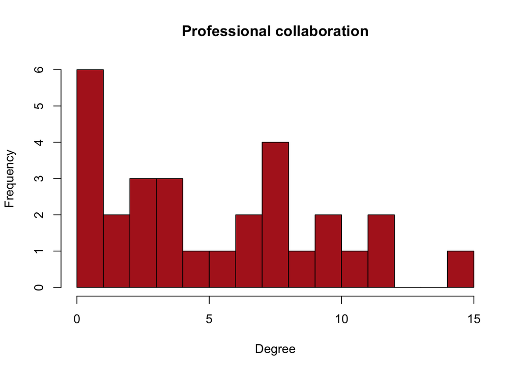

```r
collaboration %>%
  degree() %>%
  hist(
     col = "firebrick",
     xlab = "Degree",
     ylab = "Frequency",
     main = "Professional collaboration",
     breaks = min(.):max(.)
  )
```

A more elegant graph can be plotted with `ggplot2`

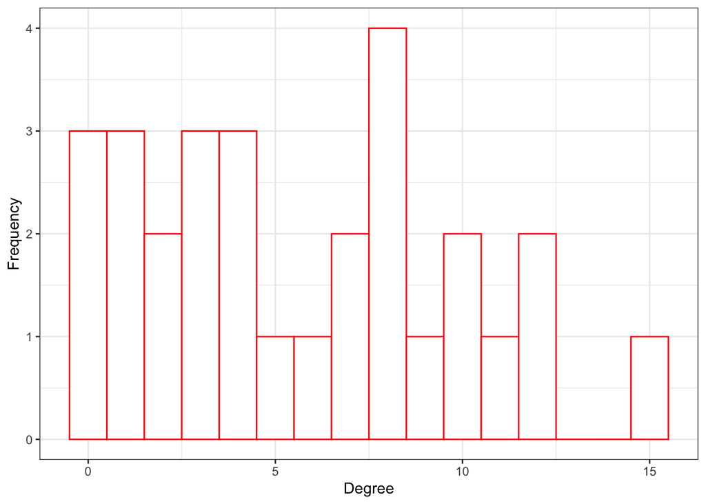

```r
collaboration %>%
  degree() %>%
  as.tibble() %>%
  ggplot() +
  geom_histogram(
    aes(value),
    binwidth = 1,
    color = "red",
    fill = "white"
  ) +
  theme_bw() +
  xlab("Degree") +
  ylab("Frequency")
```

### 5.1.2 In- and out-degree (directed)

If the network is directed: * in-degree (*popularity*): number of arcs directed to a vertex * out-degree (*activity*): number of arcs directed away from a vertex

Let’s look at the support network

```r
degree(support, mode = "in")
```

```
##  V1  V2  V3  V4  V5  V6  V7  V8  V9 V10 V11 V12 V13 V14 V15 V16 V17 V18 V19 V20
##   4   6   3   4   1   5   1   2   2   7   0   5   7   2   7   5   3   0   5   5
## V21 V22 V23 V24 V25 V26 V27 V28 V29
##   1   2   2   2   7   1   6   2   2
```

Visualization of the in-degree

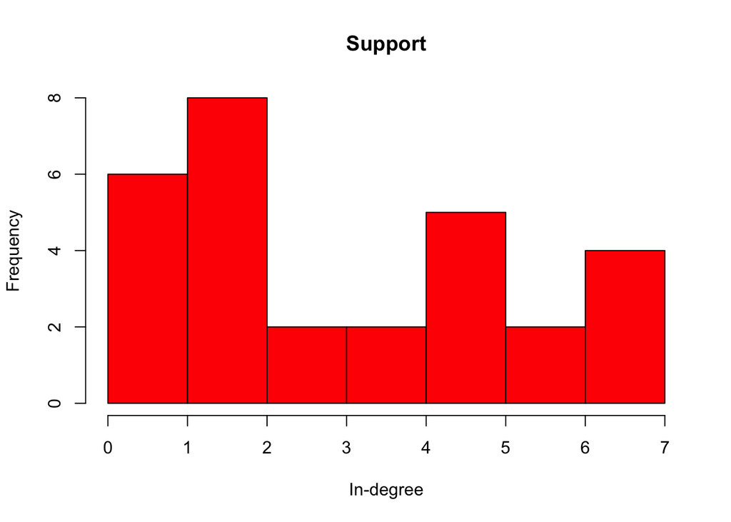

```r
degree(support, mode = "in") %>%
  hist(,
     col = "red",
     xlab = "In-degree",
     ylab = "Frequency",
     main = "Support",
     breaks = min(.):max(.)
  )
```

Visualization of the out-degree

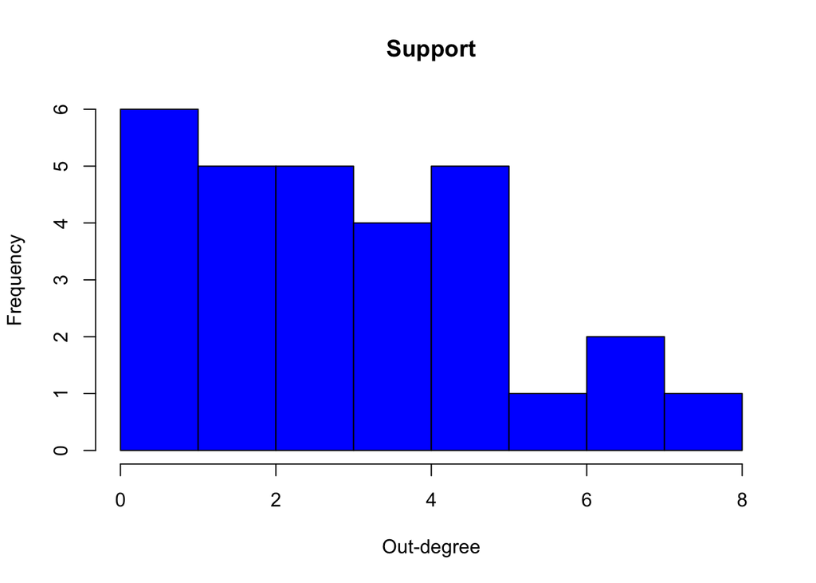

```r
degree(support, mode = "out") %>%
  hist(
     col = "blue",
     xlab = "Out-degree",
     ylab = "Frequency",
     main = "Support",
     breaks = min(.):max(.)
  )
```

Let’s plot both degree directions in the same chart: * We need `ggplot()`, which applies to `data.frames` or `tibbles` * Create a `tibble` with two columns (in- and out-degree) * In order to plot two variables in the same chart, we need to make it a tidy dataset: 1. Each variable must have its own column. 2. Each observation must have its own row. 3. Each value must have its own cell. * change dataset form to a longer form with degree in one variable and direction as the other variable  
* now we can apply `ggplot`

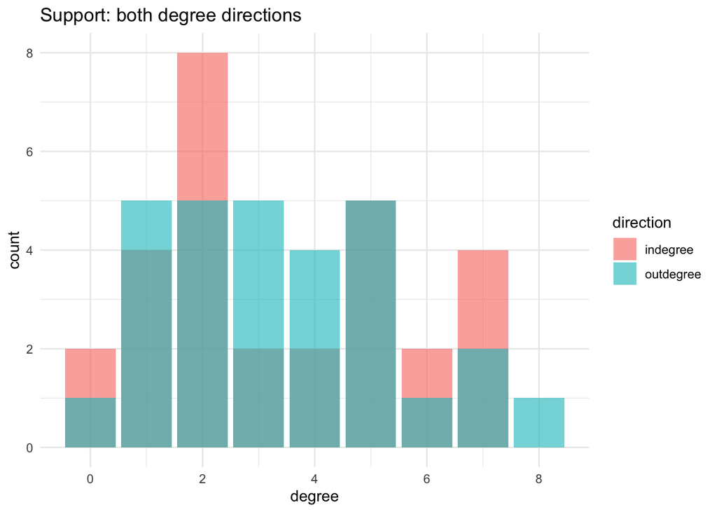

```r
tibble(
  indegree = support %>% degree(mode = "in"),
  outdegree = support %>% degree(mode = "out")
) %>%
  pivot_longer(
    cols = everything(),
    names_to = "direction",
    values_to = "degree"
  ) %>%
  ggplot(aes(x = degree, fill = direction)) +
  geom_bar(position = "identity", alpha = .6) +
  theme_minimal() +
  ggtitle("Support: both degree directions")
```

### 5.1.3 Node attributes

- We might want to analyse whether different degree values are linked to the subjects’ individual properties.
- We need to analyse node attributes

First, we need to load data on nodal attributes.

```r
(node_attributes <-
  here("data", "node-attributes.csv") %>%
  read_csv())
```

```
## ──────────────────────────────────────────────────────── Delimiter: "," chr
## (1): id dbl (18): ...1, education, age, age3, gender, seniority, seniority_rec,
## cont...
```

| ...1 | id | education | age | age3 | gender | seniority | seniority_rec | contract | field | family | children | employment | rev | motivation | gen_trust | identity | soc_capital | satisfaction |
| --- | --- | --- | --- | --- | --- | --- | --- | --- | --- | --- | --- | --- | --- | --- | --- | --- | --- | --- |
| 1 | V1 | 0 | 40 | 2 | 1 | 17 | 1 | 1 | 0 | 0 | 0 | 1 | 0 | 4 | 5166666667 | 3666666667 | 2 | 5 |
| 2 | V2 | 1 | 41 | 2 | 1 | 46 | 3 | 1 | 3 | 3 | 0 | 2 | 3 | 3 | 5333333333 | 3666666667 | 2 | 4 |
| 3 | V3 | 2 | 25 | 0 | 0 | 39 | 3 | 1 | 9 | 0 | 0 | 2 | 1 | 5 | 1833333333 | 2 | NA | 4 |
| 4 | V4 | 2 | 28 | 0 | 1 | 25 | 2 | 1 | 4 | 1 | 0 | 0 | NA | NA | 4833333333 | 4333333333 | 2 | 3 |
| 5 | V5 | 2 | 28 | 0 | 1 | 7 | 0 | 1 | 6 | 1 | 0 | 1 | 0 | 6 | 25 | 3 | 0 | 3 |
| 6 | V6 | 2 | 31 | 1 | 1 | 43 | 3 | 1 | 6 | 3 | 0 | 2 | 4 | 0 | 4 | 4666666667 | 13 | 5 |
| 7 | V7 | 3 | 39 | 1 | 1 | 17 | 1 | 1 | 7 | 3 | 1 | 0 | NA | NA | 45 | 2666666667 | 0 | 4 |
| 8 | V8 | 2 | 28 | 0 | 1 | 46 | 3 | 0 | 10 | 2 | 0 | 2 | 2 | 4 | 2333333333 | 3333333333 | 7 | 3 |
| 9 | V9 | 1 | 31 | 1 | 1 | 28 | 2 | 1 | 1 | 0 | 0 | 2 | 4 | 3 | 5333333333 | 4 | 4 | 5 |
| 10 | V10 | 1 | 28 | 0 | 1 | 46 | 3 | 1 | 1 | 0 | 0 | 2 | 0 | 2 | 45 | 4 | 6 | 6 |

[output cut: 19 more lines]

Now we can integrate our dataset of the nodes’ attributes to the graph objects.

```r
(vertex_attr(support) <- vertex_attr(collaboration) <- node_attributes)
```

| ...1 | id | education | age | age3 | gender | seniority | seniority_rec | contract | field | family | children | employment | rev | motivation | gen_trust | identity | soc_capital | satisfaction |
| --- | --- | --- | --- | --- | --- | --- | --- | --- | --- | --- | --- | --- | --- | --- | --- | --- | --- | --- |
| 1 | V1 | 0 | 40 | 2 | 1 | 17 | 1 | 1 | 0 | 0 | 0 | 1 | 0 | 4 | 5166666667 | 3666666667 | 2 | 5 |
| 2 | V2 | 1 | 41 | 2 | 1 | 46 | 3 | 1 | 3 | 3 | 0 | 2 | 3 | 3 | 5333333333 | 3666666667 | 2 | 4 |
| 3 | V3 | 2 | 25 | 0 | 0 | 39 | 3 | 1 | 9 | 0 | 0 | 2 | 1 | 5 | 1833333333 | 2 | NA | 4 |
| 4 | V4 | 2 | 28 | 0 | 1 | 25 | 2 | 1 | 4 | 1 | 0 | 0 | NA | NA | 4833333333 | 4333333333 | 2 | 3 |
| 5 | V5 | 2 | 28 | 0 | 1 | 7 | 0 | 1 | 6 | 1 | 0 | 1 | 0 | 6 | 25 | 3 | 0 | 3 |
| 6 | V6 | 2 | 31 | 1 | 1 | 43 | 3 | 1 | 6 | 3 | 0 | 2 | 4 | 0 | 4 | 4666666667 | 13 | 5 |
| 7 | V7 | 3 | 39 | 1 | 1 | 17 | 1 | 1 | 7 | 3 | 1 | 0 | NA | NA | 45 | 2666666667 | 0 | 4 |
| 8 | V8 | 2 | 28 | 0 | 1 | 46 | 3 | 0 | 10 | 2 | 0 | 2 | 2 | 4 | 2333333333 | 3333333333 | 7 | 3 |
| 9 | V9 | 1 | 31 | 1 | 1 | 28 | 2 | 1 | 1 | 0 | 0 | 2 | 4 | 3 | 5333333333 | 4 | 4 | 5 |
| 10 | V10 | 1 | 28 | 0 | 1 | 46 | 3 | 1 | 1 | 0 | 0 | 2 | 0 | 2 | 45 | 4 | 6 | 6 |

[output cut: 19 more lines]

Node attributes can be inspected

```r
collaboration %>%
  vertex_attr() %>%
  summarise(
    mean = mean(seniority),
    sd = sd(seniority)
  )
```

| mean | sd |
| --- | --- |
| 29.34483 | 14.25602 |

… and plotted

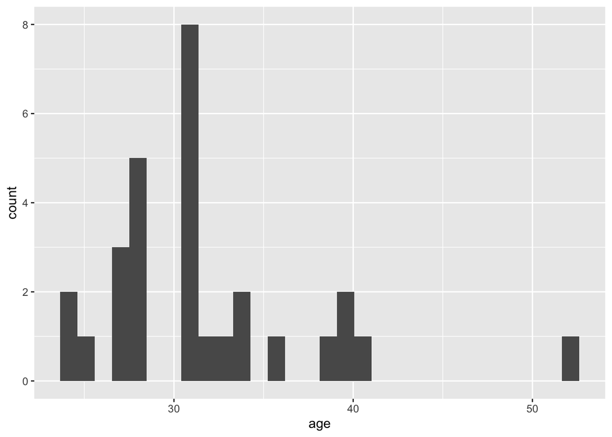

```r
collaboration %>%
  vertex_attr() %>%
  ggplot() +
  geom_histogram(aes(age))
```

Plot support w/ attributes

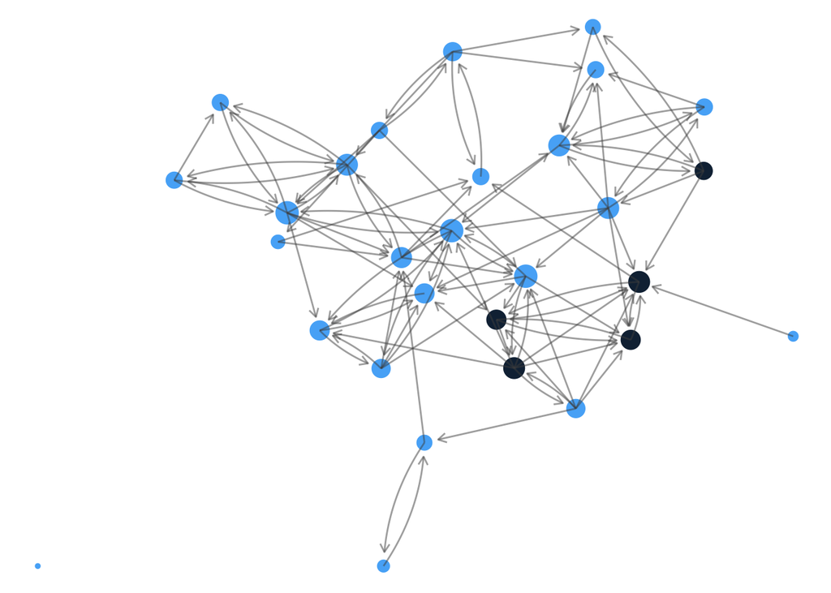

```r
support %>%
  ggraph(layout = "auto") +
  geom_node_point(
    aes(
      size = support %>% degree(),
      color = gender
    ),
    show.legend = FALSE
  ) +
  # geom_edge_link() +
  geom_edge_fan(
    arrow = arrow(length = unit(2, "mm")),
    end_cap = circle(3, "mm"),
    color = "grey30",
    width = .5,
    alpha = .5
  ) +
  theme_void()
```

Adding degree centrality as a node attribute

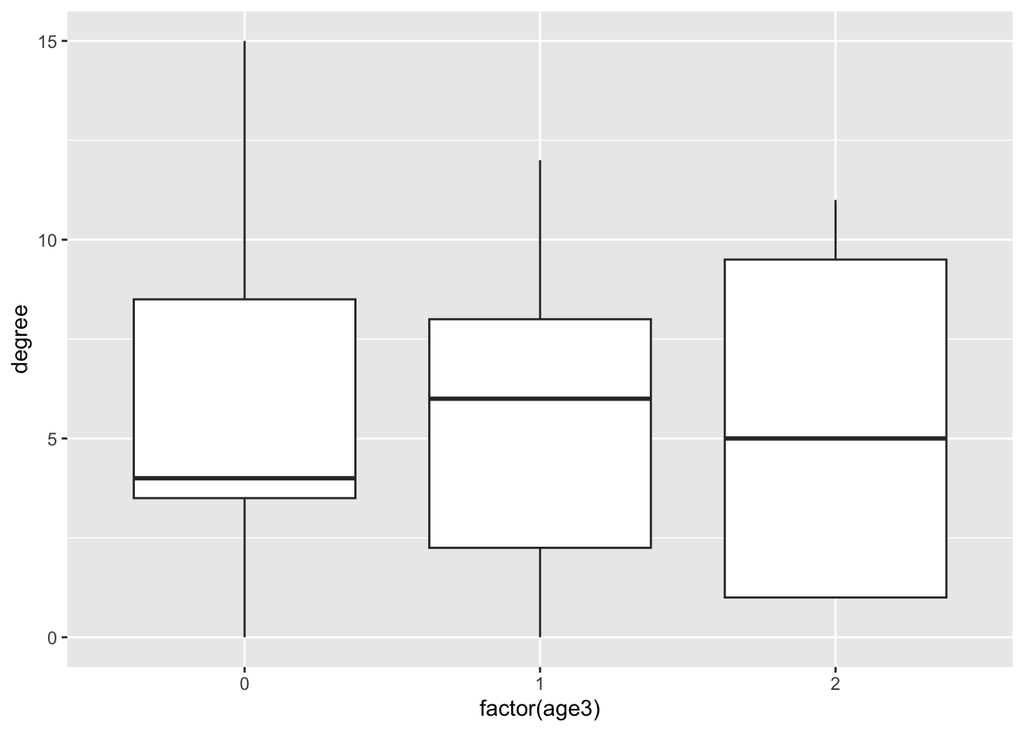

```r
collaboration %>%
  vertex_attr() %>%
  mutate(
    degree = collaboration %>% degree()
  ) %>%
  as_tibble() %>%
  ggplot() +
  geom_boxplot(aes(factor(age3), degree))
```

## 5.2 Eigenvector centrality

Example data

```r
(net1 <-
  here("data", "cent_example_1.rds") %>%
  read_rds())
```

```
## IGRAPH e0b5591 U--- 11 17 --
## + attr: cent (v/n)
## + edges from e0b5591:
##  [1] 1--11 2-- 4 3-- 5 3--11 4-- 8 5-- 9 5--11 6-- 7 6-- 8 6--10 6--11 7-- 9
## [13] 7--10 7--11 8-- 9 8--10 9--10
```

If we plot the network by visualizing degree centrality, who is the most central node?

```r
net1 %<>%
  as_tbl_graph() %>%
  activate(nodes) %>%
  mutate(name = 1:vcount(.))

net1_plot <- net1 %>%
  # as_tbl_graph() %>%
  ggraph(layout = "auto") +
  geom_edge_link(
    color = "grey",
    width = .5
  ) +
  geom_node_text(aes(label = name))
```

```
## Using "stress" as default layout
```

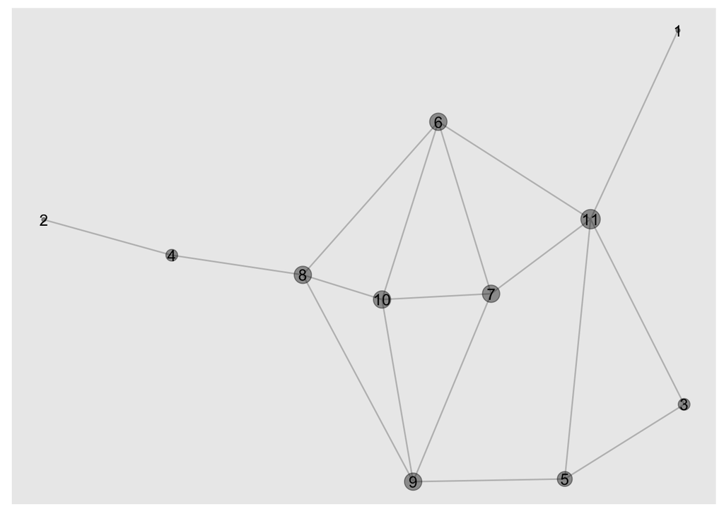

```r
net1_plot +
  geom_node_point(
    aes(size = degree(net1)),
    alpha = .4,
    show.legend = FALSE
  )
```

Who would you choose for a policy intervention to let something diffuse more rapidly?

We need to calculate *eigenvector centrality* (see slides)

```r
eigen_centrality(net1)
```

```
## $vector
##         1         2         3         4         5         6         7         8
## 0.2259630 0.0645825 0.3786244 0.2415182 0.5709057 0.9846544 1.0000000 0.8386195
##         9        10        11
## 0.9113529 0.9986474 0.8450304
##
## $value
## [1] 3.739685
##
## $options
## $options$bmat
## [1] "I"
##
## $options$n
## [1] 11
##
## $options$which
## [1] "LA"
##
## $options$nev
## [1] 1
##
## $options$tol
## [1] 0
##
## $options$ncv
## [1] 0
##
## $options$ldv
## [1] 0
##
## $options$ishift
## [1] 1
##
## $options$maxiter
## [1] 3000
##
## $options$nb
## [1] 1
##
```

[output cut: 14 more lines]

```
##
## $options$iter
## [1] 8
##
## $options$nconv
## [1] 1
##
## $options$numop
## [1] 26
##
## $options$numopb
## [1] 0
##
## $options$numreo
## [1] 11
```

- composite object
- we need to retrieve a vector
- scaled

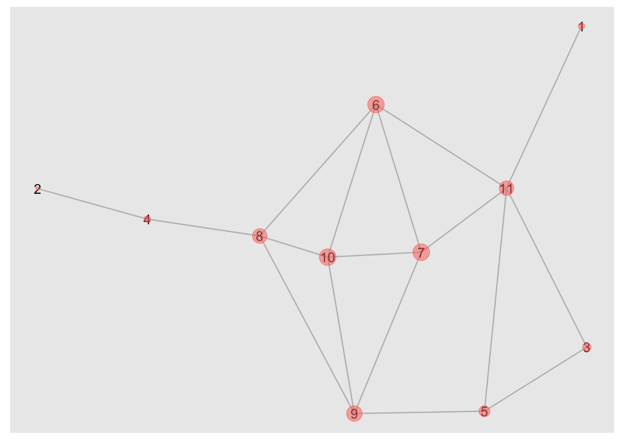

```r
net1_plot +
  geom_node_point(
    aes(
      size = (eigen_centrality(net1)$vector)^2,
      color = "red",
      alpha = .5
    ),
    show.legend = FALSE
  )
```

Compare degree centrality and eigenvector centrality

```r
tibble(
  vertex = 1:vcount(net1),
  deg = degree(net1),
  eigen = eigen_centrality(net1)$vector
)
```

| vertex | deg | eigen |
| --- | --- | --- |
| 1 | 1 | 0.2259630 |
| 2 | 1 | 0.0645825 |
| 3 | 2 | 0.3786244 |
| 4 | 2 | 0.2415182 |
| 5 | 3 | 0.5709057 |
| 6 | 4 | 0.9846544 |
| 7 | 4 | 1.0000000 |
| 8 | 4 | 0.8386195 |
| 9 | 4 | 0.9113529 |
| 10 | 4 | 0.9986474 |

[output cut: 1 more lines]

## 5.3 Betweenness centrality

Calculate

```r
betweenness(net1, normalized = TRUE)
```

```
##          1          2          3          4          5          6          7
## 0.00000000 0.00000000 0.00000000 0.20000000 0.08518519 0.21851852 0.05925926
##          8          9         10         11
## 0.36296296 0.16296296 0.02962963 0.32592593
```

Plot

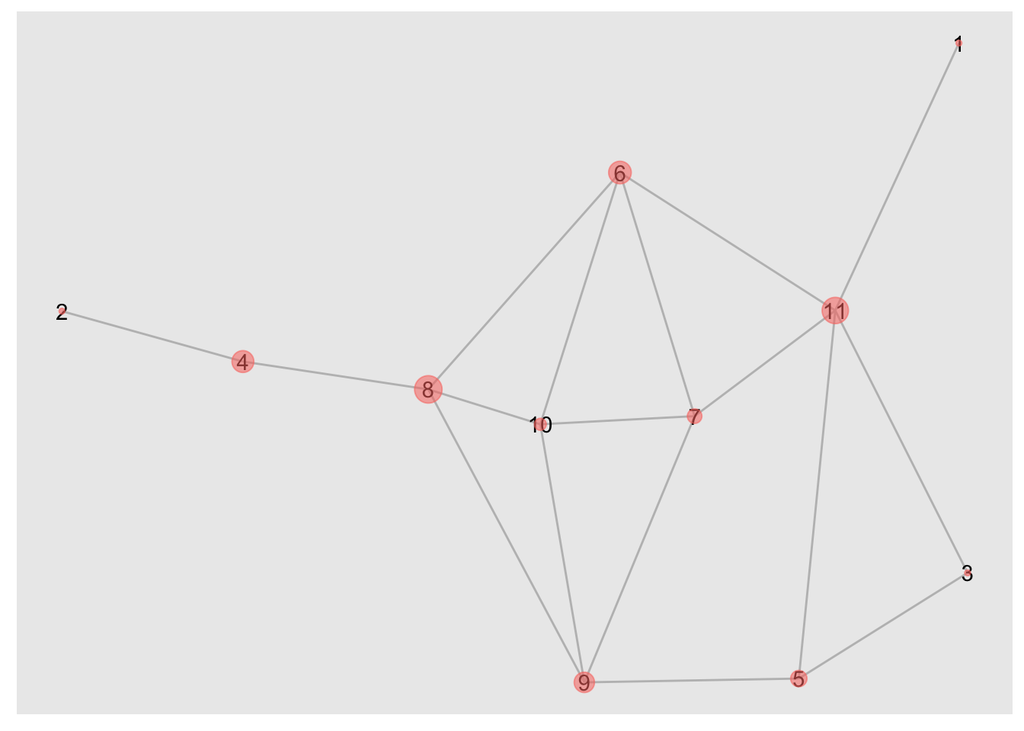

```r
net1_plot +
  geom_node_point(
    aes(
      size = betweenness(net1, normalized = TRUE),
      color = "red",
      alpha = .5
    ),
    show.legend = FALSE
  )
```

Compare degree centrality, eigenvector centrality, and betweenness centrality

```r
tibble(
  vertex = 1:vcount(net1),
  deg = degree(net1),
  eigen = eigen_centrality(net1)$vector,
  btw = betweenness(net1)
)
```

| vertex | deg | eigen | btw |
| --- | --- | --- | --- |
| 1 | 1 | 0.2259630 | 0.000000 |
| 2 | 1 | 0.0645825 | 0.000000 |
| 3 | 2 | 0.3786244 | 0.000000 |
| 4 | 2 | 0.2415182 | 9.000000 |
| 5 | 3 | 0.5709057 | 3.833333 |
| 6 | 4 | 0.9846544 | 9.833333 |
| 7 | 4 | 1.0000000 | 2.666667 |
| 8 | 4 | 0.8386195 | 16.333333 |
| 9 | 4 | 0.9113529 | 7.333333 |
| 10 | 4 | 0.9986474 | 1.333333 |

[output cut: 1 more lines]

## 5.4 Centrality in advice

Loading data

```r
(advice <-
  here("data", "advice-coworking.txt") %>%
  read_tsv(col_names = FALSE) %>%
  as.matrix() %>%
  graph_from_adjacency_matrix())
```

```
## IGRAPH 6012415 DN-- 29 120 --
## + attr: name (v/c)
## + edges from 6012415 (vertex names):
##  [1] X1 ->X2  X1 ->X12 X2 ->X4  X2 ->X8  X2 ->X13 X2 ->X15 X2 ->X16 X2 ->X28
##  [9] X3 ->X6  X3 ->X10 X3 ->X15 X3 ->X16 X3 ->X19 X3 ->X20 X3 ->X23 X3 ->X25
## [17] X3 ->X26 X4 ->X1  X4 ->X2  X4 ->X15 X4 ->X27 X4 ->X28 X5 ->X9  X5 ->X24
## [25] X6 ->X13 X6 ->X15 X6 ->X16 X6 ->X17 X6 ->X20 X6 ->X21 X6 ->X23 X7 ->X2
## [33] X8 ->X2  X8 ->X4  X8 ->X13 X8 ->X15 X8 ->X28 X9 ->X2  X9 ->X4  X9 ->X6
## [41] X9 ->X14 X9 ->X15 X9 ->X23 X10->X3  X10->X13 X10->X15 X10->X16 X10->X19
## [49] X10->X21 X10->X25 X11->X15 X12->X2  X12->X6  X12->X7  X13->X15 X13->X16
## [57] X14->X2  X14->X4  X14->X9  X14->X25 X15->X6  X15->X13 X15->X16 X15->X21
## + ... omitted several edges
```

Add attributes

```r
vertex_attr(advice) <- node_attributes
```

Plot degree centrality vs. betweenness centrality

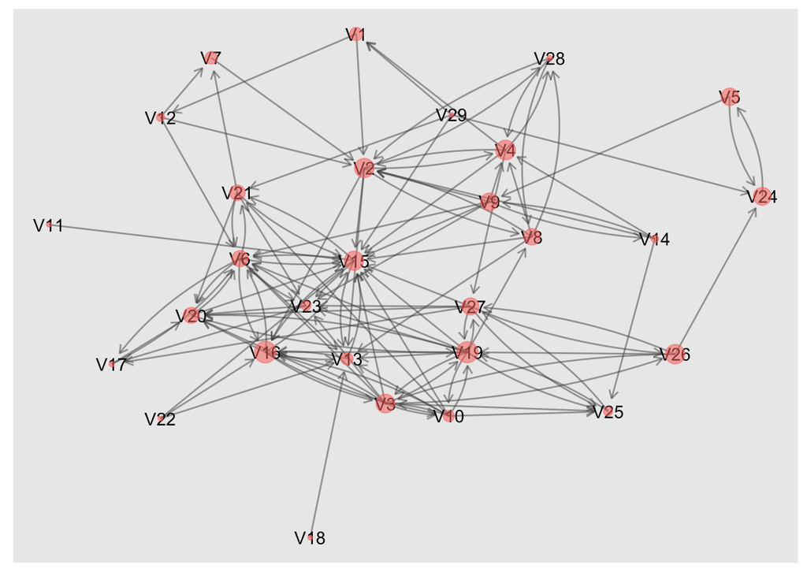

```r
advice_plot <- advice %>%
  ggraph(layout = "kk") +
  geom_edge_fan(
    arrow = arrow(length = unit(2, "mm")),
    end_cap = circle(3, "mm"),
    color = "grey30",
    width = .5,
    alpha = .5
  ) +
  geom_node_text(aes(label = id))

advice_plot +
  geom_node_point(
    aes(
      # size = degree(advice, mode = "in"),
      size = betweenness(advice, directed = TRUE),
      color = "red",
      alpha = .5
    ),
    show.legend = FALSE
  )
```

- Clustering and components
- For small networks, Girvan-Newman algorithm is one of the most used and fastest
- it maximises modularity (the degree to which the network is divided into clusters with possible maximal density within and possible minimal connection between)
- it uses edge betweenness to find and remove central edges

```r
cluster_edge_betweenness(support)
```

```
## IGRAPH clustering edge betweenness, groups: 11, mod: 0.29
## + groups:
##   $`1`
##   [1]  1  2  4  9 14 21 28 29
##
##   $`2`
##   [1] 3
##
##   $`3`
##   [1] 5
##
##   $`4`
##   + ... omitted several groups/vertices
```

plot

```r
support_plot <-
  support %>%
  ggraph(layout = "auto") +
  geom_edge_fan(
    arrow = arrow(length = unit(2, "mm")),
    end_cap = circle(3, "mm"),
    color = "grey30",
    width = .5,
    alpha = .5
  )
```

```
## Using "stress" as default layout
```

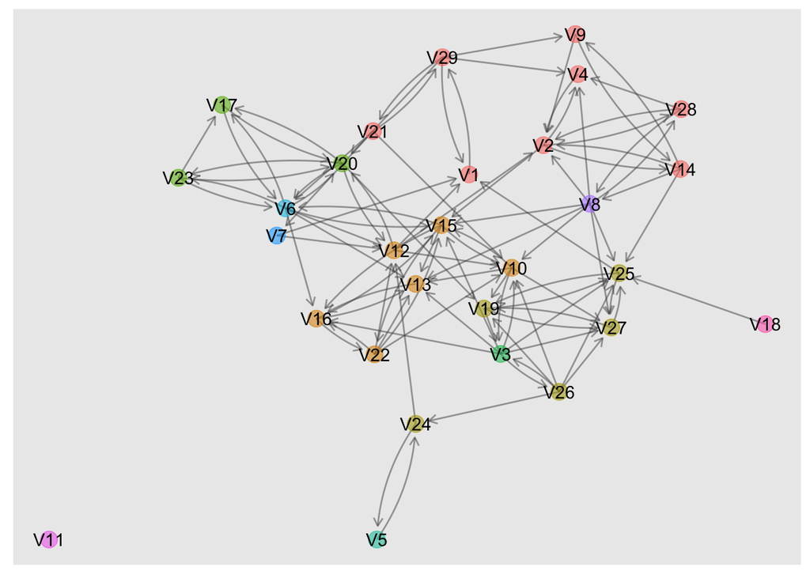

```r
support_plot +
  geom_node_point(
    aes(
      color = factor(group_edge_betweenness()),
      size = 5,
      alpha = .5
    ),
    show.legend = FALSE
  ) +
  geom_node_text(aes(label = id))
```

# 6 Network processes

## 6.1 Reciprocity

Loading a suite of packages including `sna`, `network`, and `ergm` which we’ll use the make statistical inference. We load it here and not at the beginning of the notebook because it can rise conflicts with some `igraph` functions that we have used so far.

```r
library(statnet)
```

Creating a network object, which is needed by functions included in the `sna` and `ergm` packages

```r
(support_net <-
  network(
    x = as_adjacency_matrix(support),
    node_attributes
  ))
```

```
##  Network attributes:
##   vertices = 29
##   directed = TRUE
##   hyper = FALSE
##   loops = FALSE
##   multiple = FALSE
##   bipartite = FALSE
##   total edges= 99
##     missing edges= 0
##     non-missing edges= 99
##
##  Vertex attribute names:
##     ...1 age age3 children contract education employment family field gen_trust gender id identity motivation rev satisfaction seniority seniority_rec soc_capital vertex.names
##
## No edge attributes
```

Inspecting attributes in `network`

```r
support_net %v% "age"
```

```
##  [1] 40 41 25 28 28 31 39 28 31 28 33 52 31 27 31 31 32 31 34 40 28 31 24 27 31
## [26] 24 34 27 36
```

Let’s calculate the number of complete dyads

```r
mutuality(support_net) # number of complete dyads (pairs with reciprocal ties)
```

```
## Mut
##  25
```

```r
sna::dyad.census(support_net) # 812 dyads, 406 pairs of nodes (29 * 28 / 2), 99 dyads with at least one tie, of which 25 are symmetrical, which means 50 ties are in symmetric dyads + 49 which are not in symmetric dyads = 99 dyads with a tie
```

```
##      Mut Asym Null
## [1,]  25   49  332
```

What should we compare it to?

- fix number of nodes
- assume a data-generating process

Let’s compare it with a random network with 29 nodes. We need to specify a probability for ties to occur. let’s pick random chance

```r
rnd_net <-
  rgraph(
    n = 29,
    m = 1,
    tprob = .5
  )
```

- 0.5 is clearly unrealistic, so let’s take the density of our empirical network as the baseline probability of ties to occurr
- Let’s simulate a whole distribution of random graphs conditioned to n = 29 and probability = .12

```r
rnd_net <-
  rgraph(
    n = 29,
    m = 1000,
    tprob = gden(support_net)
  )
```

Our empirically observed statistic doesn’t even lie within the stochastic distribution!

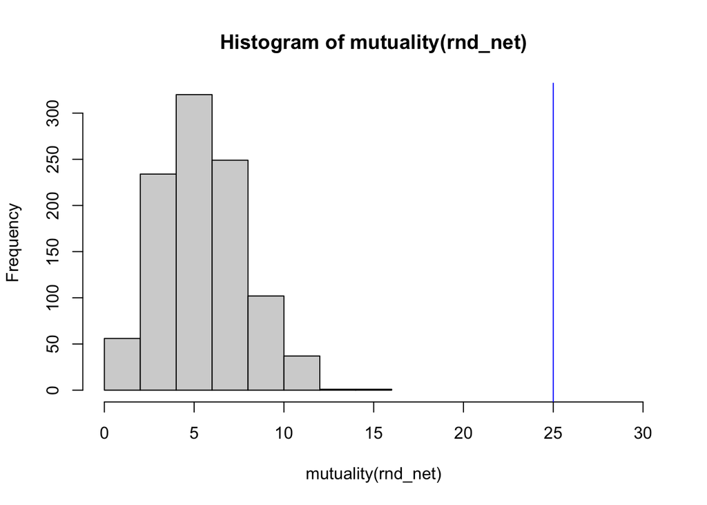

```r
hist(mutuality(rnd_net), xlim = c(0, 30))
abline(v = mutuality(support_net), col="blue")
```

# 7 ERGM

Let’s start by fitting an ERGM with just probability of edges in it (kind of intercept in a regression model)

```r
m0 <- support_net ~ edges
summary(m0)
```

```
## edges
##    99
```

- We’ll look for a distribution of random graphs with 29 nodes that has 99 as expected number of edges.
- In order to do it, we search the right parameter estimate

```r
fit0 <- ergm(m0)
```

```
## Starting maximum pseudolikelihood estimation (MPLE):
```

```
## Evaluating the predictor and response matrix.
```

```
## Maximizing the pseudolikelihood.
```

```
## Finished MPLE.
```

```
## Stopping at the initial estimate.
```

```
## Evaluating log-likelihood at the estimate.
```

```r
summary(fit0)
```

```
## Call:
## ergm(formula = m0)
##
## Maximum Likelihood Results:
##
##       Estimate Std. Error MCMC % z value Pr(>|z|)
## edges  -1.9744     0.1073      0  -18.41   <1e-04 ***
## ---
## Signif. codes:  0 '***' 0.001 '**' 0.01 '*' 0.05 '.' 0.1 ' ' 1
##
##      Null Deviance: 1125.7  on 812  degrees of freedom
##  Residual Deviance:  602.1  on 811  degrees of freedom
##
## AIC: 604.1  BIC: 608.8  (Smaller is better. MC Std. Err. = 0)
```

- It’s very quick because there are no dependencies!
- No need for MCMC MLE. We used Maximum Pseudo-Likelihood Estimation (no simulation) (almost a logistic regression)

From log-odds to odds-ratio:

```r
coef(fit0) # log-odds
```

```
##     edges
## -1.974362
```

```r
exp(coef(fit0)) / (1 + exp(coef(fit0)))
```

```
##     edges
## 0.1219212
```

The log-odds (ln(p/(i-p))) of a tie to be present in the network (according to our model) is -1.97 * the change-statistic (delta) in the number of ties, which is 1 because every tie addition increases the statistic of the edge configuration by 1

```r
coef(fit0) * 1
```

```
##     edges
## -1.974362
```

To obtain the probability, we take the inverse of the logit

```r
exp(coef(fit0)) / (1 + exp(coef(fit0)))
```

```
##     edges
## 0.1219212
```

Model with reciprocity (dyadic independence model)

```r
m1 <- update.formula(m0, . ~ . + mutual)
summary(m1)
```

```
##  edges mutual
##     99     25
```

Fitting the model to the data

```r
fit1 <- ergm(m1)
```

```
## Starting maximum pseudolikelihood estimation (MPLE):
```

```
## Evaluating the predictor and response matrix.
```

```
## Maximizing the pseudolikelihood.
```

```
## Finished MPLE.
```

```
## Starting Monte Carlo maximum likelihood estimation (MCMLE):
```

```
## Iteration 1 of at most 60:
```

```
## Optimizing with step length 1.0000.
```

```
## The log-likelihood improved by 0.0011.
```

[output not shown]

```r
summary(fit1)
```

```
## Call:
## ergm(formula = m1)
##
## Monte Carlo Maximum Likelihood Results:
##
##        Estimate Std. Error MCMC % z value Pr(>|z|)
## edges   -2.5994     0.1764      0 -14.736   <1e-04 ***
## mutual   2.6162     0.3658      0   7.151   <1e-04 ***
## ---
## Signif. codes:  0 '***' 0.001 '**' 0.01 '*' 0.05 '.' 0.1 ' ' 1
##
##      Null Deviance: 1126  on 812  degrees of freedom
##  Residual Deviance:  548  on 810  degrees of freedom
##
## AIC: 552  BIC: 561.4  (Smaller is better. MC Std. Err. = 0.6832)
```

More reciprocal dyads in our network than in random graphs with 29 nodes and .12 density

- We want to control for transitive closure, which might confound the effect of reciprocity.
- We’re going to add `gwesp` to the model (Geometrically Weighted Edgewise Shared Partners) with .5 as a fixed smoothing constant

```r
m2 <- update.formula(m1, . ~ . + gwesp(.5, fixed = T))
summary(m2)
```

```
##           edges          mutual gwesp.fixed.0.5
##        99.00000        25.00000        81.46703
```

- Estimates of this model rarely converge. If we fail fitting this model, it’s because the model needs more information on the network.
- Let’s add open triads as a configuration

```r
m3 <- update.formula(m2, . ~ . + twopath)
fit3 <- ergm(m3)
```

```
## Starting maximum pseudolikelihood estimation (MPLE):
```

```
## Evaluating the predictor and response matrix.
```

```
## Maximizing the pseudolikelihood.
```

```
## Finished MPLE.
```

```
## Starting Monte Carlo maximum likelihood estimation (MCMLE):
```

```
## Iteration 1 of at most 60:
```

```
## Optimizing with step length 1.0000.
```

```
## The log-likelihood improved by 0.8947.
```

```
## Estimating equations are not within tolerance region.
```

```
## Iteration 2 of at most 60:
```

```
## Optimizing with step length 1.0000.
```

```
## The log-likelihood improved by 0.0361.
```

[output not shown]

```r
summary(fit3)
```

```
## Call:
## ergm(formula = m3)
##
## Monte Carlo Maximum Likelihood Results:
##
##                 Estimate Std. Error MCMC % z value Pr(>|z|)
## edges           -2.25307    0.32703      0  -6.889   <1e-04 ***
## mutual           2.01452    0.36874      0   5.463   <1e-04 ***
## gwesp.fixed.0.5  1.06762    0.15828      0   6.745   <1e-04 ***
## twopath         -0.24091    0.05413      0  -4.450   <1e-04 ***
## ---
## Signif. codes:  0 '***' 0.001 '**' 0.01 '*' 0.05 '.' 0.1 ' ' 1
##
##      Null Deviance: 1125.7  on 812  degrees of freedom
##  Residual Deviance:  494.2  on 808  degrees of freedom
##
## AIC: 502.2  BIC: 521  (Smaller is better. MC Std. Err. = 0.5544)
```

Let’s now control for social selection along age

```r
m4 <- update.formula(m3, . ~ . + nodeicov("age") + nodeocov("age") + absdiff("age"))
fit4 <- ergm(m4)
```

```
## Starting maximum pseudolikelihood estimation (MPLE):
```

```
## Evaluating the predictor and response matrix.
```

```
## Maximizing the pseudolikelihood.
```

```
## Finished MPLE.
```

```
## Starting Monte Carlo maximum likelihood estimation (MCMLE):
```

```
## Iteration 1 of at most 60:
```

```
## Optimizing with step length 1.0000.
```

```
## The log-likelihood improved by 1.0064.
```

```
## Estimating equations are not within tolerance region.
```

```
## Iteration 2 of at most 60:
```

```
## Optimizing with step length 1.0000.
```

```
## The log-likelihood improved by 0.1868.
```

```
## Estimating equations are not within tolerance region.
```

```
## Iteration 3 of at most 60:
```

```
## Optimizing with step length 1.0000.
```

```
## The log-likelihood improved by 0.4920.
```

```
## Estimating equations are not within tolerance region.
```

```
## Iteration 4 of at most 60:
```

```
## Optimizing with step length 1.0000.
```

```
## The log-likelihood improved by 0.9067.
```

```
## Estimating equations are not within tolerance region.
```

```
## Estimating equations did not move closer to tolerance region more than 1 time(s) in 4 steps; increasing sample size.
```

```
## Iteration 5 of at most 60:
```

```
## Optimizing with step length 1.0000.
```

```
## The log-likelihood improved by 0.4773.
```

```
## Estimating equations are not within tolerance region.
```

```
## Iteration 6 of at most 60:
```

```
## Optimizing with step length 1.0000.
```

```
## The log-likelihood improved by 0.1749.
```

```
## Estimating equations are not within tolerance region.
```

```
## Iteration 7 of at most 60:
```

```
## Optimizing with step length 1.0000.
```

```
## The log-likelihood improved by 0.0669.
```

[output not shown]

```r
summary(fit4)
```

```
## Call:
## ergm(formula = m4)
##
## Monte Carlo Maximum Likelihood Results:
##
##                 Estimate Std. Error MCMC % z value Pr(>|z|)
## edges           -3.15391    0.76549      0  -4.120   <1e-04 ***
## mutual           2.15869    0.36711      0   5.880   <1e-04 ***
## gwesp.fixed.0.5  1.03748    0.15600      0   6.651   <1e-04 ***
## twopath         -0.23186    0.05660      0  -4.097   <1e-04 ***
## nodeicov.age     0.04514    0.01901      0   2.374   0.0176 *
## nodeocov.age    -0.01351    0.01911      0  -0.707   0.4796
## absdiff.age     -0.03189    0.02073      0  -1.539   0.1239
## ---
## Signif. codes:  0 '***' 0.001 '**' 0.01 '*' 0.05 '.' 0.1 ' ' 1
##
##      Null Deviance: 1125.7  on 812  degrees of freedom
##  Residual Deviance:  487.9  on 805  degrees of freedom
##
## AIC: 501.9  BIC: 534.8  (Smaller is better. MC Std. Err. = 0.8173)
```

Based on the estimated models, we have good evidence of reciprocation driving the formation of the support network.